# 3 A multi-variable standard language attitude index (SLAI)

Based on Dollinger’s 2023 survey on CanE lg. attitudes

Authors

Affiliations

Lars Hinrichs

The University of Texas at Austin

Stefan Dollinger

University of British Columbia

## 1 Data prep

We update the data to include responses only from respondents with one of the following values for `province`:

```
 [1] "alberta"                   "british columbia"
 [3] "manitoba"                  "new brunswick"
 [5] "newfoundland and labrador" "northern territories"
 [7] "nova scotia"               "nunavut"
 [9] "ontario"                   "prince edward island"
[11] "quebec"                    "saskatchewan"
[13] "yukon"
```

Preview of our data. We want only canadian respondents, with `gender` reordered.

```
# A tibble: 2,682 × 36
   cool    multiling umultiling comf_non_eng media priv  st_heard st_descr zed
   <chr>   <chr>     <chr>      <chr>        <chr> <chr> <chr>    <chr>    <chr>
 1 strong… definite… no         <NA>         extr… "yes" yes      "yes bu… both
 2 strong… probably… no         <NA>         impo… "no"  yes      "yes bu… zed
 3 strong… probably… yes        extremely c… unim… "tha… no       "yes i … zee
 4 strong… probably… yes        moderately … impo… "no"  yes      "yes bu… both
 5 strong… probably… yes        moderately … unim… "tha… not sure  <NA>    zee
 6 strong… probably… no         <NA>         impo… "tha… no        <NA>    zed
 7 agree   probably… no         <NA>         impo… "tha… not sure  <NA>    zee
 8 agree   definite… yes        neither com… <NA>  "tha… no        <NA>    zee
 9 strong… definite… no         <NA>         impo… "tha… no        <NA>    zed
10 strong… definite… no         <NA>         impo… "tha… yes      "yes bu… zed
# ℹ 2,672 more rows
# ℹ 27 more variables: spell <chr>, spell_uni <chr>, distinct <chr>,
#   same_ew <chr>, celebs <chr>, prestige <chr>, rec_cdns <chr>,
#   software <chr>, dictionary <chr>, recog_eh <chr>, cdn_sorry <chr>,
#   engl_able <chr>, fr_able <chr>, ind_able <chr>, beyond_ef <chr>,
#   cdn_way <chr>, age <int>, country <chr>, province <chr>, gender <fct>,
#   edu_comp <chr>, degree_year <chr>, region <chr>, eui <chr>, …
```

Next, we address comparability among survey questions. Some questions use a 4-point Likert scale, others a 5-point scale. We rescale the 4-point Likert items to a 5-point scale in order to make them comparable with the 5-point items.

## 2 Forming the SLAI

This study forms a mean index of responses to the following questions:

### 2.1 DVs

Response variables (ordinal or categorical):

### 2.2 IVs

Here, we perform the rescaling and form the attitude index by forming `rowMeans`. To prepare for plotting, we also filter out respondents that didn’t answer one of the questions.

```r
df_canada <- df_canada %>%
  mutate(
    spell_uni_scaled = spell_uni_num,
    distinct_scaled  = rescale_4_to_5(distinct_num),
    cdn_way_scaled   = rescale_4_to_5(cdn_way_num),
    attitude_index_scaled = rowMeans(
      cbind(spell_uni_scaled, distinct_scaled, cdn_way_scaled, spell_num),
      na.rm = TRUE
    )
  )

# Filter complete cases for plotting
# and fix edu_comp factor
df_plot <- df_canada %>%
  filter(!is.na(attitude_index_scaled), !is.na(edu_comp), !is.na(gender),
         !is.na(umultiling)) %>%
  mutate(
    edu_comp = str_trim(edu_comp),
    edu_comp = factor(
      edu_comp,
      levels = c(
        "other",
        "elementary school",
        "high school",
        "undergraduate degree",
        "graduate degree",
        "postgraduate degree"
      )
    )
  ) %>%
  filter(! edu_comp == "other")
```

### 2.3 Univariate dependency plotting

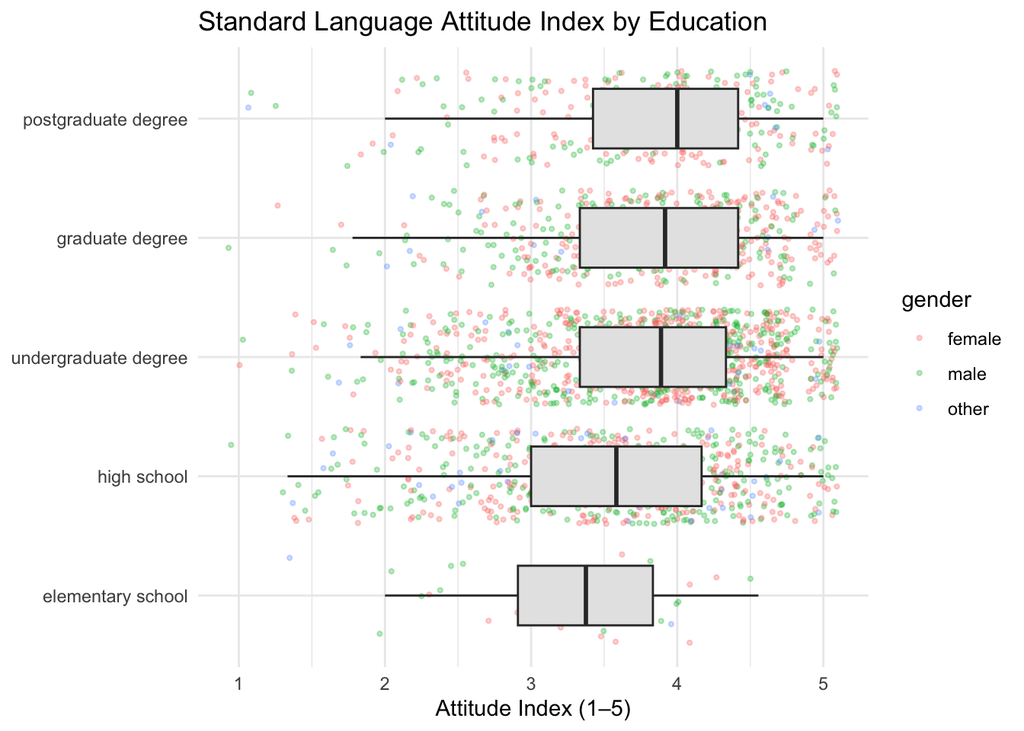

Now plot the interaction education x gender.

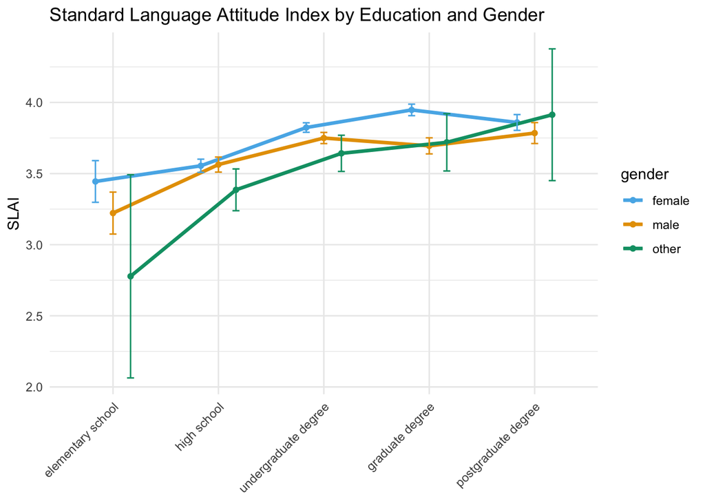

The difference between male and female speakers is clearest among respondents with a graduate degree.

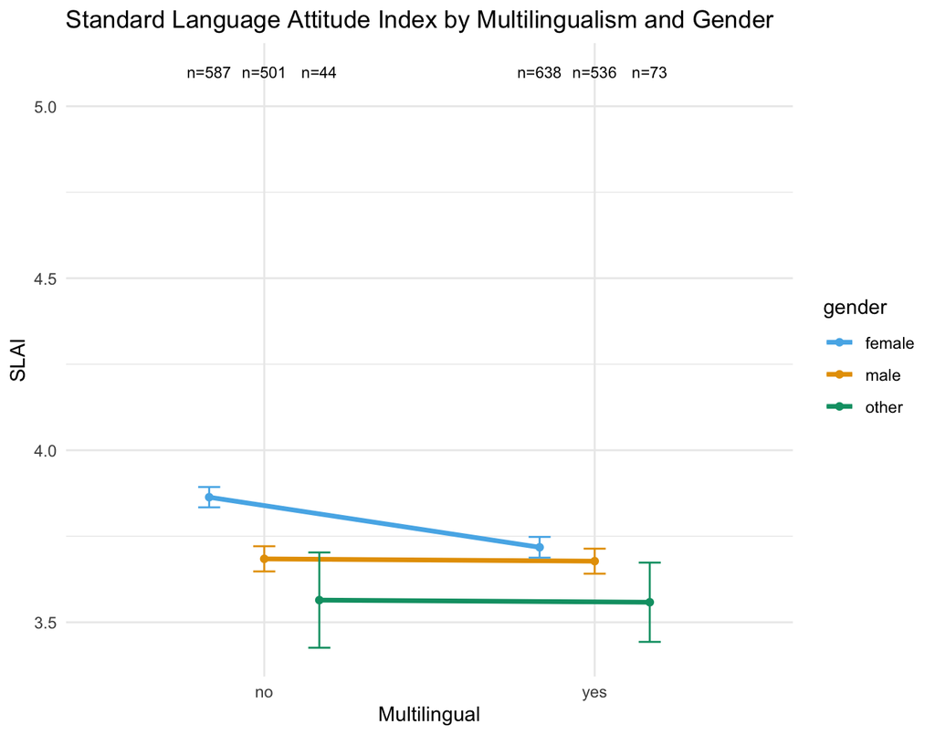

The multilingual factor makes the most difference among female respondents. Women who are multilingual are less positively oriented toward StCanE. **This is surprising.**

## 3 Statistical tests

```
Call:
lm(formula = attitude_index_scaled ~ province + gender + edu_comp,
    data = df_plot)

Residuals:
     Min       1Q   Median       3Q      Max
-2.89939 -0.46385  0.06949  0.56233  1.71217

Coefficients:
                                  Estimate Std. Error t value Pr(>|t|)
(Intercept)                        3.61460    0.12906  28.006  < 2e-16 ***
provincebritish columbia          -0.40387    0.04650  -8.685  < 2e-16 ***
provincemanitoba                  -0.07403    0.05589  -1.324 0.185481
provincenew brunswick             -0.19687    0.12051  -1.634 0.102464
provincenewfoundland and labrador -0.26928    0.12737  -2.114 0.034599 *
provincenova scotia               -0.05890    0.12178  -0.484 0.628700
provincenunavut                    0.97497    0.77045   1.265 0.205831
provinceontario                   -0.09197    0.05011  -1.835 0.066581 .
provinceprince edward island      -0.24739    0.10969  -2.255 0.024205 *
provincequebec                    -0.37361    0.08051  -4.640 3.67e-06 ***
provincesaskatchewan              -0.01838    0.05903  -0.311 0.755608
provinceyukon                     -0.45801    0.23478  -1.951 0.051202 .
gendermale                        -0.11355    0.03277  -3.465 0.000539 ***
genderother                       -0.17551    0.07473  -2.348 0.018932 *
edu_comphigh school                0.19065    0.12614   1.511 0.130803
edu_compundergraduate degree       0.35882    0.12559   2.857 0.004313 **
edu_compgraduate degree            0.41979    0.12821   3.274 0.001075 **
edu_comppostgraduate degree        0.43803    0.13055   3.355 0.000805 ***
---
Signif. codes:  0 '***' 0.001 '**' 0.01 '*' 0.05 '.' 0.1 ' ' 1

Residual standard error: 0.769 on 2361 degrees of freedom
Multiple R-squared:  0.07363,   Adjusted R-squared:  0.06695
F-statistic: 11.04 on 17 and 2361 DF,  p-value: < 2.2e-16
```

### 3.1 Anova test

```
Anova Table (Type II tests)

Response: attitude_index_scaled
           Sum Sq   Df F value    Pr(>F)
province    63.61   11  9.7780 < 2.2e-16 ***
gender       8.79    2  7.4289 0.0006078 ***
edu_comp    23.13    4  9.7777 7.637e-08 ***
Residuals 1396.30 2361
---
Signif. codes:  0 '***' 0.001 '**' 0.01 '*' 0.05 '.' 0.1 ' ' 1
```

### 3.2 Interactions included in model

```
Anova Table (Type II tests)

Response: attitude_index_scaled
                 Sum Sq   Df F value    Pr(>F)
province          62.41   11  9.5894 < 2.2e-16 ***
gender             8.79    2  7.4263 0.0006094 ***
edu_comp          23.13    4  9.7743 7.689e-08 ***
gender:edu_comp    4.25    8  0.8984 0.5167688
Residuals       1392.05 2353
---
Signif. codes:  0 '***' 0.001 '**' 0.01 '*' 0.05 '.' 0.1 ' ' 1
```

This shows that the interaction term is not significant (at all), so we can stop talking about it.

### 3.3 Pairwise comparisons

Between education levels.

```
$emmeans
 edu_comp             emmean     SE   df lower.CL upper.CL
 elementary school      3.42 0.1430 2361     3.14     3.70
 high school            3.61 0.0774 2361     3.46     3.76
 undergraduate degree   3.78 0.0762 2361     3.63     3.92
 graduate degree        3.84 0.0795 2361     3.68     3.99
 postgraduate degree    3.85 0.0849 2361     3.69     4.02

Results are averaged over the levels of: province, gender
Confidence level used: 0.95

$contrasts
 contrast                                   estimate     SE   df t.ratio
 elementary school - high school             -0.1907 0.1260 2361  -1.511
 elementary school - undergraduate degree    -0.3588 0.1260 2361  -2.857
 elementary school - graduate degree         -0.4198 0.1280 2361  -3.274
 elementary school - postgraduate degree     -0.4380 0.1310 2361  -3.355
 high school - undergraduate degree          -0.1682 0.0405 2361  -4.153
 high school - graduate degree               -0.2291 0.0480 2361  -4.772
 high school - postgraduate degree           -0.2474 0.0549 2361  -4.503
 undergraduate degree - graduate degree      -0.0610 0.0435 2361  -1.401
 undergraduate degree - postgraduate degree  -0.0792 0.0516 2361  -1.535
 graduate degree - postgraduate degree       -0.0182 0.0575 2361  -0.317
 p.value
  0.5551
  0.0350
  0.0095
  0.0072
  0.0003
  <.0001
  0.0001
  0.6270
  0.5395
  0.9978

Results are averaged over the levels of: province, gender
P value adjustment: tukey method for comparing a family of 5 estimates
```

A better view of the output of the Anova for main effects.

[output not shown]

### 3.4 Visualize pairwise comparisons with `province` and `umultilingual`

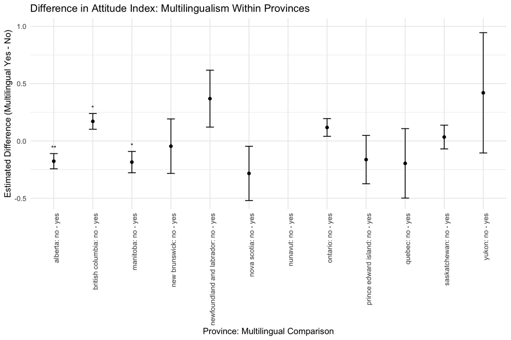

### 3.5 Multivariate model plot

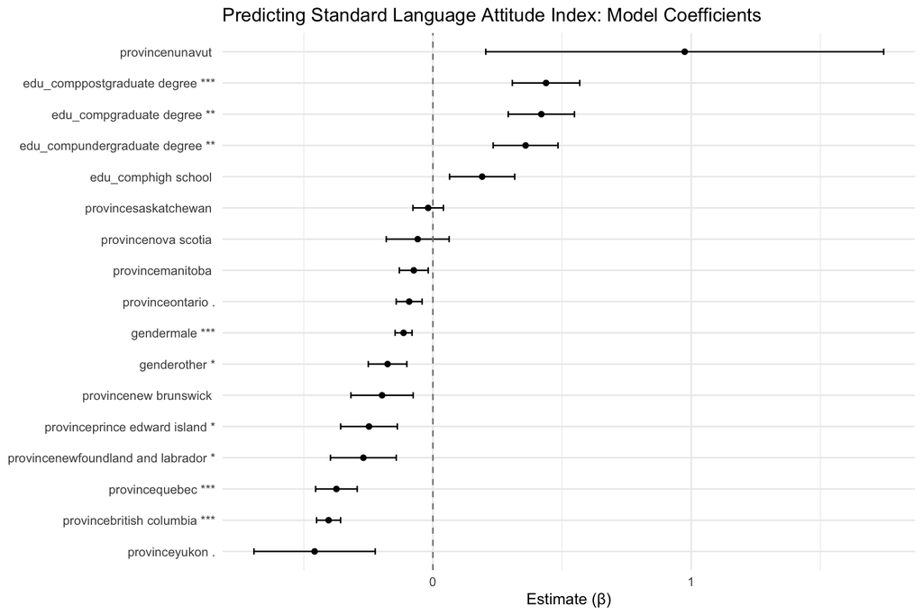